# Homework 3

Ryan

2/10/2022

#### Due: 2/17/2022 before 11:59pm. Submit in Canvas (file upload).

## Git Links

Ryan Repository: https://github.com/ryancorydon8/practice1-ryancorydon8

Emma Repository: https://github.com/epodlich/practice1-epodlich

I made 4 pull requests on Emma’s repository after I forked her repository and made changes under mine. There was at least 18 commits.

Emma made 3 pull requests on my repository and merged successfully. There was at least 14 commits.

## Question 2: 3 Tips to make git hub easier

First I would say how to understand a forked repository and make a pull request into the main repository. The most important thing is practice with git because after multiple attempts it becomes a lot easier to understand. As well understand R and pushing the files from R into git. This takes practice and to understand it best it is important to make sure you clone the repository and connect it via version control in R.

## Question 3 Graph

Generate the graph of LifExp vs. gdpPercap for US, Canada (fixed data) and Australia by RMarkdown based on the data set “gapminder-5060”, like what we did in the class.  
Please use Github to collaborate on this problem. For example, one member can create the plot of US in his/her repository. The other member will fork this repository, add the result for the second country, and make a pull request for merging into the main repository. Each member should at least analyze one country and make at least one pull request. **Please submit the RMarkdown file, the output file, and the screen shot of the successful pull request and the merge.**

# Add the United States - Ryan

```r
library(ggplot2)
life5060 <- read.csv("https://raw.githubusercontent.com/epodlich/practice1-ryancorydon8/main/gapminder-5060%20.csv")
View(life5060)
dim(life5060)
```

```
## [1] 568   6
```

```r
us <- life5060[life5060$country == "United States", ]
head(us)
```

```
##           country continent year lifeExp       pop gdpPercap
## 537 United States  Americas 1952   68.44 157553000  13990.48
## 538 United States  Americas 1957   69.49 171984000  14847.13
## 539 United States  Americas 1962   70.21 186538000  16173.15
## 540 United States  Americas 1967   70.76 198712000  19530.37
```

```r
dim(us)
```

```
## [1] 4 6
```

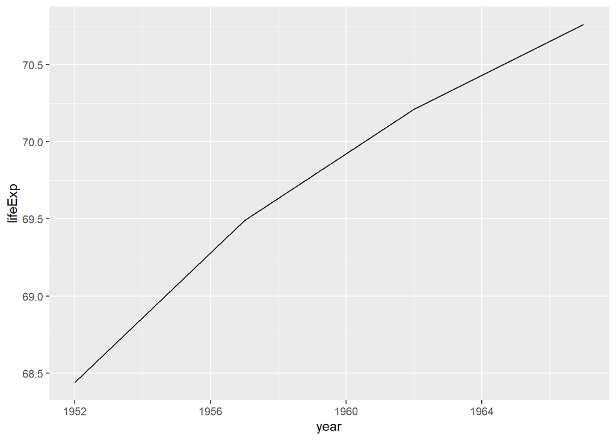

```r
ggplot(data = us, aes(x = year, y = lifeExp)) + geom_line()
```

```r
us_fixed = us
us_fixed$lifeExp[us_fixed$year==1957] = 69.49
us_fixed
```

```
##           country continent year lifeExp       pop gdpPercap
## 537 United States  Americas 1952   68.44 157553000  13990.48
## 538 United States  Americas 1957   69.49 171984000  14847.13
## 539 United States  Americas 1962   70.21 186538000  16173.15
## 540 United States  Americas 1967   70.76 198712000  19530.37
```

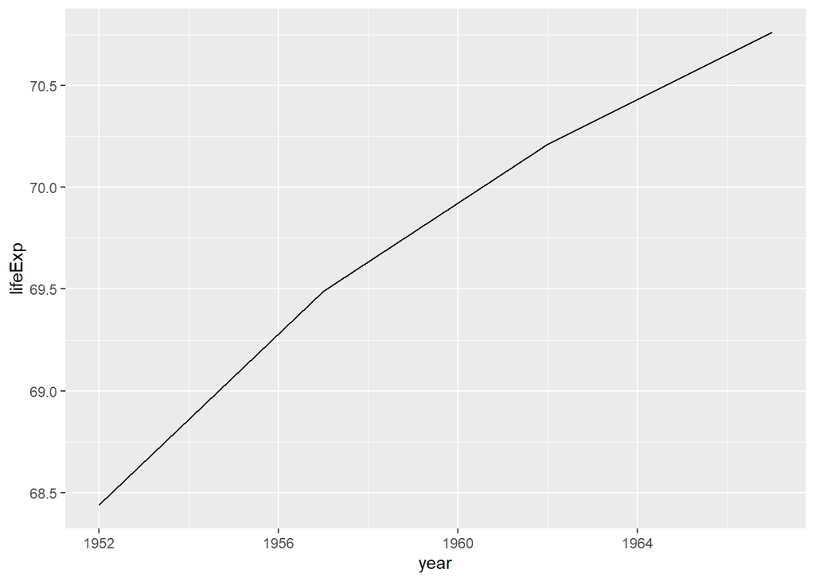

```r
ggplot(data = us_fixed, aes(x = year, y = lifeExp)) + geom_line()
```

# Unfixed Data Plot

```r
life5060 <- read.csv("https://raw.githubusercontent.com/epodlich/practice1-ryancorydon8/main/gapminder-5060%20.csv")
View(life5060)
dim(life5060)
```

```
## [1] 568   6
```

```r
canada <- life5060[life5060$country == "Canada", ]

head(canada)
```

```
##    country continent year   lifeExp      pop gdpPercap
## 81  Canada  Americas 1952     68.75 14785584  11367.16
## 82  Canada  Americas 1957 999999.00 17010154  12489.95
## 83  Canada  Americas 1962     71.30 18985849  13462.49
## 84  Canada  Americas 1967     72.13 20819767  16076.59
```

```r
dim(canada)
```

```
## [1] 4 6
```

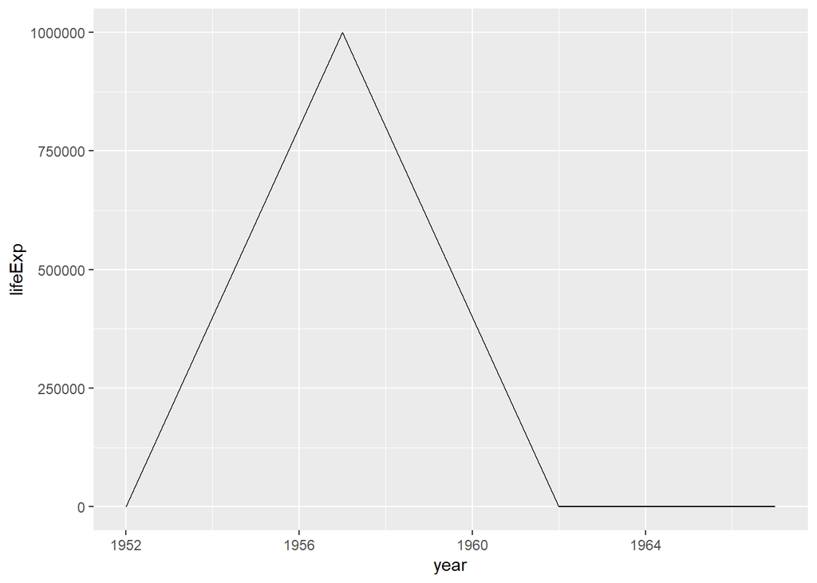

```r
ggplot(data = canada, aes(x = year, y = lifeExp)) + geom_line()
```

# Fixed Data Plot

```r
canada_fixed = canada
canada_fixed$lifeExp[canada_fixed$year==1957] = 69.96
canada_fixed
```

```
##    country continent year lifeExp      pop gdpPercap
## 81  Canada  Americas 1952   68.75 14785584  11367.16
## 82  Canada  Americas 1957   69.96 17010154  12489.95
## 83  Canada  Americas 1962   71.30 18985849  13462.49
## 84  Canada  Americas 1967   72.13 20819767  16076.59
```

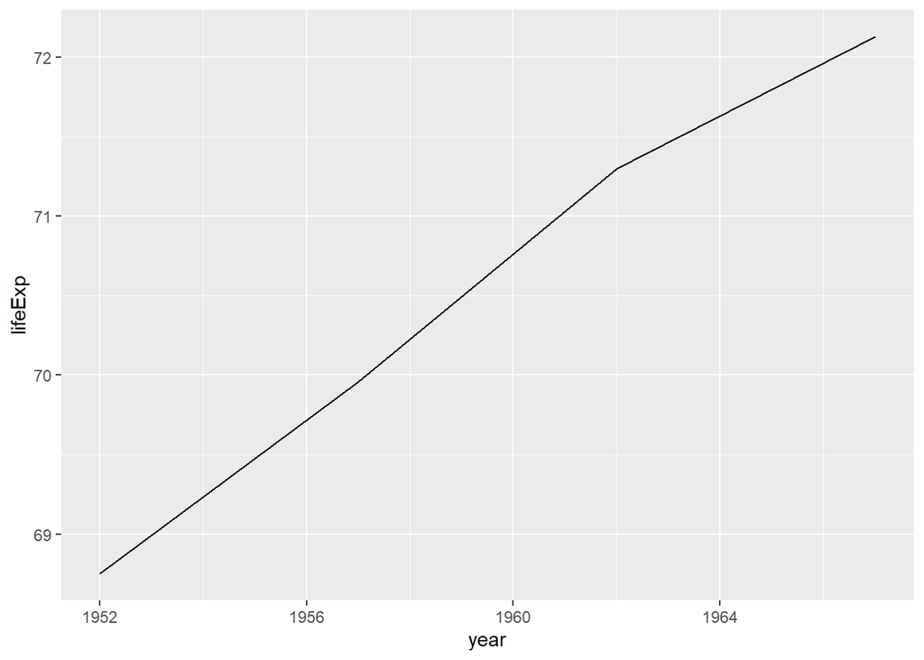

```r
ggplot(data = canada_fixed, aes(x = year, y = lifeExp)) + geom_line()
```

## Question Four

Write a paragraph (~200 words) describing an example of what you consider data science. Write your paragraph in R Markdown. Include at least a. one link to a chart or an image and b. at least one itemized or enumerated list.

Data science is the extraction of knowledge from complex data through several different techniques like machine learning. A great example that I will discuss and am extremely interested in is sports data and analytics. You can use this to find numerous different types of data to help a team or a player. For example if a coach has data on a player he can make informed decisions that can effect game strategy or selection when it comes to using a certain player at a certain time based on the data. AS well, fan behavior can be generated when organizations produce special events to see if more fans arrive, as well if players play better at said special events. I like looking at prime time stats compared to regular time stats because it is interesting to see how different players play on the big stage. Data science and technology has changed the way sports have been played and it is only making the game more advanced than ever imagined. This is an example of how Kirk Cousins plays during specific times and the odds of them performing better or worse. https://ftw.usatoday.com/wp-content/uploads/sites/90/2022/09/Screen-Shot-2022-09-20-at-10.35.55-AM.png

## This is how I rank my interest in different sports I would consider working in after I graduate.

1. Soccer
2. Football
3. Baseball
4. Golf
5. Hockey
6. Basketball